# R语言统计分析

# 第八章：相关分析与基础回归

本章介绍变量间关系的分析方法，包括相关分析和线性回归。相关分析用于度量变量间的关联程度，回归分析则用于建立变量间的数学模型。

## 8.1 Pearson相关分析

### 数学基础

**Pearson相关系数**：

$$r = \frac{\sum(X_i - \bar{X})(Y_i -
\bar{Y})}{\sqrt{\sum(X_i - \bar{X})^2 \sum(Y_i -
\bar{Y})^2}}$$

**性质**： - 取值范围：[-1, 1] - r = 0：无线性相关 - r > 0：正相关 - r < 0：负相关 - |r| 接近1：强相关

**假设条件**： 1. 两个变量都是连续变量 2. 两个变量服从二元正态分布 3. 关系是线性的 4. 无显著异常值

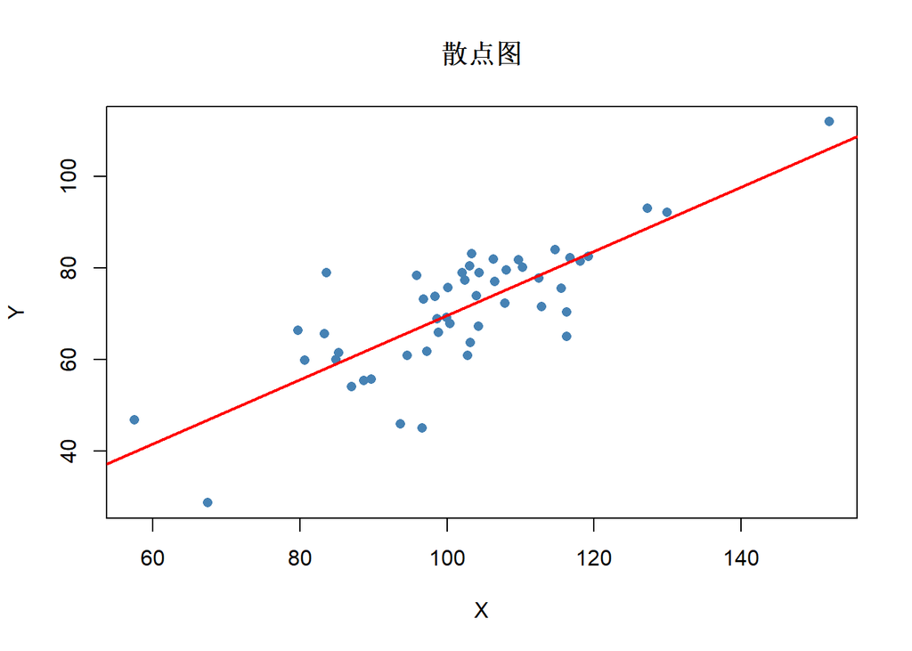

```r
# Pearson相关分析示例
set.seed(111111)

# 生成相关数据
n <- 50
x <- rnorm(n, mean = 100, sd = 15)
y <- 0.7 * x + rnorm(n, mean = 0, sd = 10)

# 散点图
plot(x, y, main = "散点图", xlab = "X", ylab = "Y", pch = 16, col = "steelblue")
abline(lm(y ~ x), col = "red", lwd = 2)
```

```r
# 计算Pearson相关系数
cor_xy <- cor(x, y)
cat("Pearson相关系数:", cor_xy, "\n")
```

```
## Pearson相关系数: 0.7931909
```

```r
# 相关系数的假设检验
cor_test <- cor.test(x, y)
cor_test
```

```
##
##  Pearson's product-moment correlation
##
## data:  x and y
## t = 9.024, df = 48, p-value = 6.537e-12
## alternative hypothesis: true correlation is not equal to 0
## 95 percent confidence interval:
##  0.6607185 0.8777471
## sample estimates:
##       cor
## 0.7931909
```

```r
# 提取结果
cat("相关系数:", cor_test$estimate, "\n")
```

```
## 相关系数: 0.7931909
```

```r
cat("95%置信区间:", cor_test$conf.int, "\n")
```

```
## 95%置信区间: 0.6607185 0.8777471
```

```r
cat("t统计量:", cor_test$statistic, "\n")
```

```
## t统计量: 9.024023
```

```r
cat("p值:", cor_test$p.value, "\n")
```

```
## p值: 6.537419e-12
```

```r
# 相关系数矩阵
set.seed(222222)
data_matrix <- data.frame(
  x1 = rnorm(100),
  x2 = rnorm(100),
  x3 = rnorm(100)
)
data_matrix$x4 <- 0.5 * data_matrix$x1 + 0.3 * data_matrix$x2 + rnorm(100, sd = 0.5)

# 相关系数矩阵
cor_matrix <- cor(data_matrix)
cor_matrix
```

```
##            x1          x2          x3          x4
## x1 1.00000000  0.19367575  0.04872119  0.67136898
## x2 0.19367575  1.00000000 -0.03092974  0.51238135
## x3 0.04872119 -0.03092974  1.00000000 -0.04532995
## x4 0.67136898  0.51238135 -0.04532995  1.00000000
```

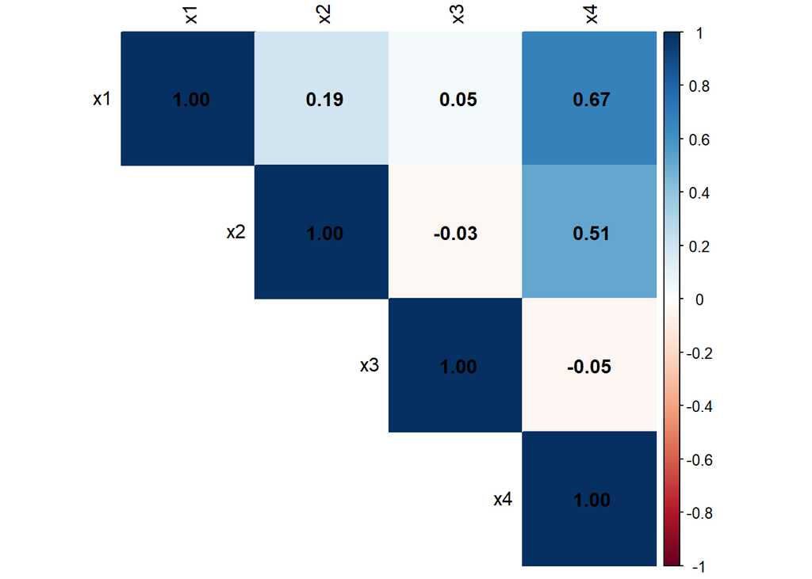

```r
# 可视化相关矩阵
library(corrplot)
corrplot(cor_matrix, method = "color", type = "upper",
         tl.col = "black", addCoef.col = "black")
```

## 8.2 相关系数的假设检验与置信区间

### 数学基础

**检验统计量**：
$$t =
r\sqrt{\frac{n-2}{1-r^2}}$$

服从自由度为n-2的t分布。

```r
# 相关系数检验示例

# 不同相关强度的比较
set.seed(333333)

# 强正相关
x1 <- rnorm(50)
y1 <- 0.9 * x1 + rnorm(50, sd = 0.3)

# 弱正相关
x2 <- rnorm(50)
y2 <- 0.3 * x2 + rnorm(50, sd = 0.8)

# 无相关
x3 <- rnorm(50)
y3 <- rnorm(50)

# 比较检验结果
cor_test1 <- cor.test(x1, y1)
cor_test2 <- cor.test(x2, y2)
cor_test3 <- cor.test(x3, y3)

cat("强正相关: r =", cor_test1$estimate, "p =", cor_test1$p.value, "\n")
```

```
## 强正相关: r = 0.9537358 p = 1.060319e-26
```

```r
cat("弱正相关: r =", cor_test2$estimate, "p =", cor_test2$p.value, "\n")
```

```
## 弱正相关: r = 0.45306 p = 0.000953545
```

```r
cat("无相关: r =", cor_test3$estimate, "p =", cor_test3$p.value, "\n")
```

```
## 无相关: r = 0.06427032 p = 0.657459
```

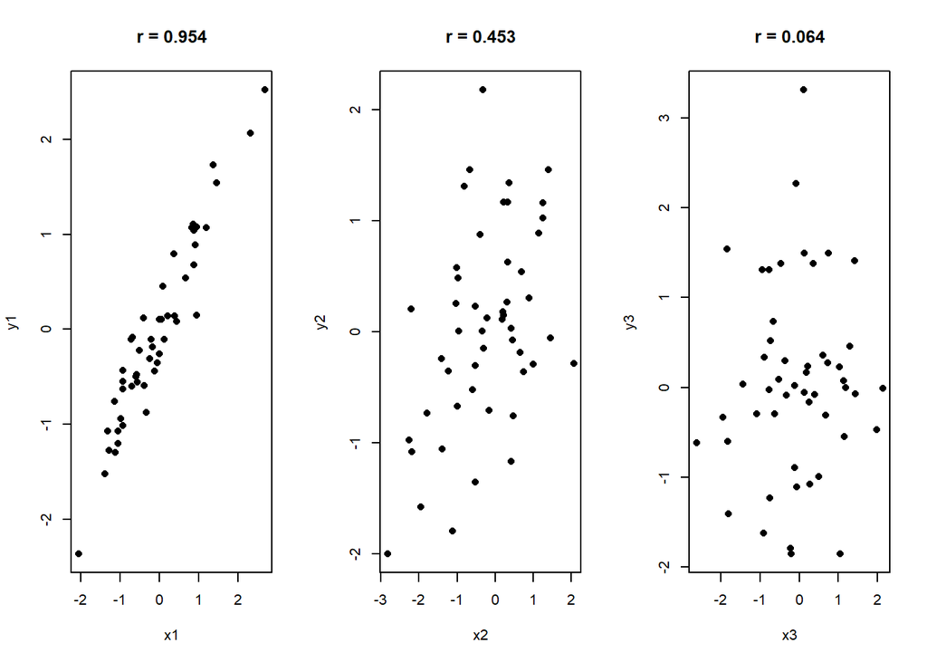

```r
# 可视化比较
par(mfrow = c(1, 3))
plot(x1, y1, main = paste("r =", round(cor_test1$estimate, 3)), pch = 16)
plot(x2, y2, main = paste("r =", round(cor_test2$estimate, 3)), pch = 16)
plot(x3, y3, main = paste("r =", round(cor_test3$estimate, 3)), pch = 16)
```

```r
par(mfrow = c(1, 1))

# Fisher Z变换计算置信区间
fisher_z <- atanh(cor_xy)
se_z <- 1 / sqrt(n - 3)
z_lower <- fisher_z - 1.96 * se_z
z_upper <- fisher_z + 1.96 * se_z
ci_lower <- tanh(z_lower)
ci_upper <- tanh(z_upper)
cat("Fisher Z变换置信区间: [", ci_lower, ",", ci_upper, "]\n")
```

```
## Fisher Z变换置信区间: [ 0.6607155 , 0.8777483 ]
```

## 8.3 偏相关分析

### 数学基础

**偏相关系数**：在控制其他变量影响后，两个变量之间的相关程度。

$$r_{xy.z} = \frac{r_{xy} -
r_{xz}r_{yz}}{\sqrt{(1-r_{xz}^2)(1-r_{yz}^2)}}$$

```r
# 偏相关分析示例
set.seed(444444)
n <- 100

# 生成三个相关变量
z <- rnorm(n, mean = 50, sd = 10)
x <- 0.7 * z + rnorm(n, sd = 5)
y <- 0.6 * z + rnorm(n, sd = 5)

# 创建数据框
partial_data <- data.frame(x = x, y = y, z = z)

# 简单相关
cor(partial_data)
```

```
##           x         y         z
## x 1.0000000 0.5364063 0.8320560
## y 0.5364063 1.0000000 0.7420707
## z 0.8320560 0.7420707 1.0000000
```

```r
# x和y的简单相关
cor_xy <- cor(x, y)
cat("x和y的简单相关:", cor_xy, "\n")
```

```
## x和y的简单相关: 0.5364063
```

```r
# 偏相关（控制z）
# 使用ppcor包
library(ppcor)
pcor_result <- pcor(partial_data)
pcor_result$estimate
```

```
##            x          y         z
## x  1.0000000 -0.2179486 0.7671659
## y -0.2179486  1.0000000 0.6317601
## z  0.7671659  0.6317601 1.0000000
```

```r
# 提取偏相关系数
cat("控制z后，x和y的偏相关:", pcor_result$estimate["x", "y"], "\n")
```

```
## 控制z后，x和y的偏相关: -0.2179486
```

```r
# 偏相关检验
pcor.test(x, y, z)
```

```
##     estimate    p.value statistic   n gp  Method
## 1 -0.2179486 0.03022388 -2.199418 100  1 pearson
```

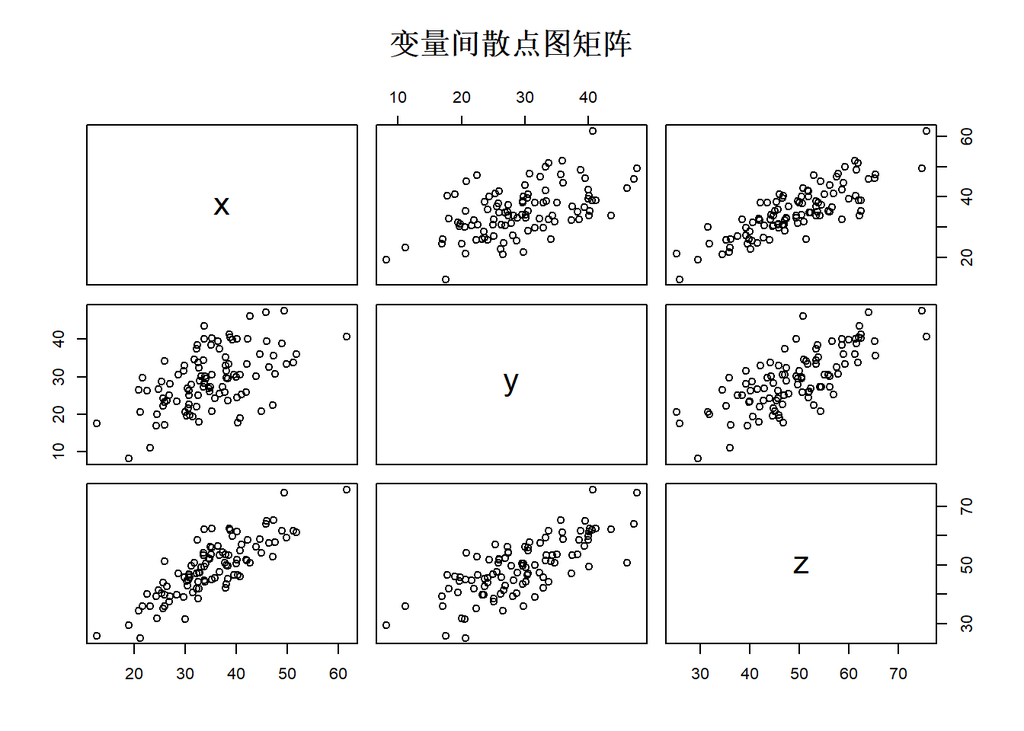

```r
# 可视化
pairs(partial_data, main = "变量间散点图矩阵")
```

## 8.4 简单线性回归

### 数学基础

**回归模型**：
$$Y = \beta_0
+ \beta_1 X + \epsilon$$

**最小二乘估计**：
$$\hat{\beta}_1 = \frac{\sum(X_i - \bar{X})(Y_i -
\bar{Y})}{\sum(X_i - \bar{X})^2}$$

$$\hat{\beta}_0 = \bar{Y} -
\hat{\beta}_1\bar{X}$$

```r
# 简单线性回归示例
# 场景：研究身高与体重的关系

set.seed(555555)
height <- rnorm(50, mean = 170, sd = 8)
weight <- 0.8 * height - 60 + rnorm(50, sd = 5)

# 创建数据框
body_data <- data.frame(height = height, weight = weight)

# 散点图
plot(height, weight, main = "身高与体重的关系",
     xlab = "身高", ylab = "体重", pch = 16, col = "steelblue")

# 拟合线性回归模型
lm_model <- lm(weight ~ height, data = body_data)
lm_model
```

```
##
## Call:
## lm(formula = weight ~ height, data = body_data)
##
## Coefficients:
## (Intercept)       height
##     -56.038        0.778
```

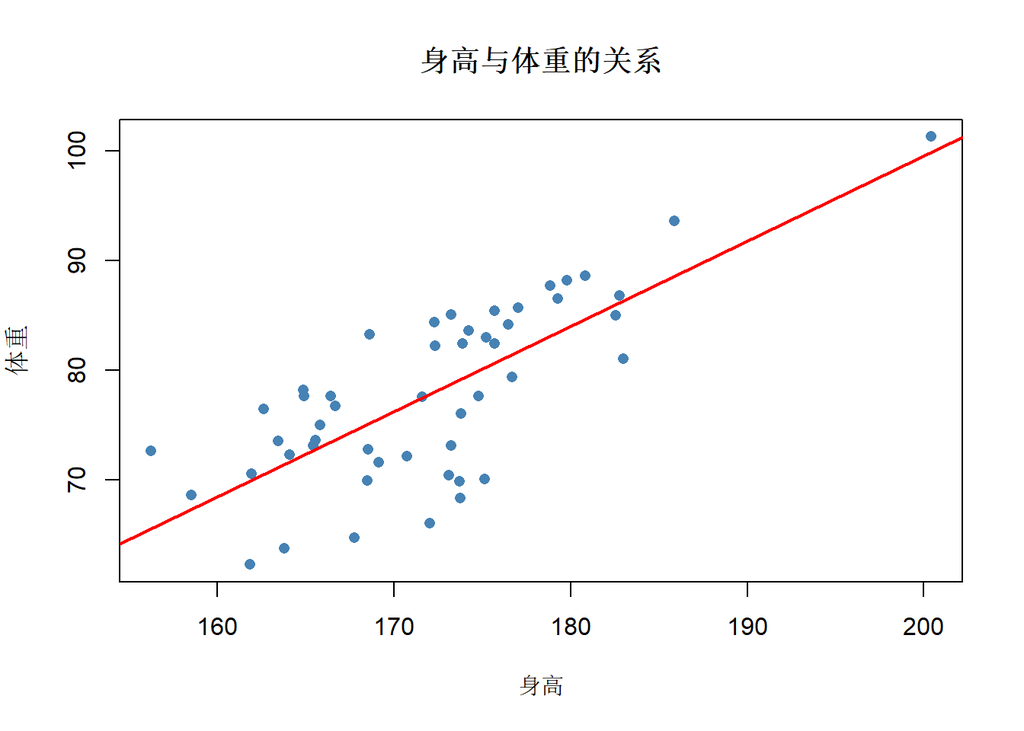

```r
# 回归直线
abline(lm_model, col = "red", lwd = 2)
```

```r
# 详细结果
summary(lm_model)
```

```
##
## Call:
## lm(formula = weight ~ height, data = body_data)
##
## Residuals:
##     Min      1Q  Median      3Q     Max
## -11.775  -3.748   1.351   4.143   8.071
##
## Coefficients:
##              Estimate Std. Error t value Pr(>|t|)
## (Intercept) -56.03843   17.01130  -3.294  0.00186 **
## height        0.77799    0.09877   7.877 3.38e-10 ***
## ---
## Signif. codes:  0 '***' 0.001 '**' 0.01 '*' 0.05 '.' 0.1 ' ' 1
##
## Residual standard error: 5.415 on 48 degrees of freedom
## Multiple R-squared:  0.5638, Adjusted R-squared:  0.5547
## F-statistic: 62.04 on 1 and 48 DF,  p-value: 3.383e-10
```

```r
# 提取系数
coefficients(lm_model)
```

```
## (Intercept)      height
## -56.0384349   0.7779929
```

```r
# 置信区间
confint(lm_model)
```

```
##                   2.5 %      97.5 %
## (Intercept) -90.2419427 -21.8349271
## height        0.5794004   0.9765855
```

```r
# 回归系数的解释
cat("截距:", coefficients(lm_model)[1], "\n")
```

```
## 截距: -56.03843
```

```r
cat("斜率:", coefficients(lm_model)[2], "\n")
```

```
## 斜率: 0.7779929
```

```r
cat("解释：身高每增加1cm，体重平均增加",
    round(coefficients(lm_model)[2], 2), "kg\n")
```

```
## 解释：身高每增加1cm，体重平均增加 0.78 kg
```

## 8.5 回归系数的假设检验

### 数学基础

**t检验**：
$$t =
\frac{\hat{\beta}_j}{SE(\hat{\beta}_j)}$$

**决定系数R²**：
$$R^2 =
\frac{SS_{regression}}{SS_{total}} = 1 -
\frac{SS_{residual}}{SS_{total}}$$

```r
# 回归系数检验示例

# 模型摘要
model_summary <- summary(lm_model)

# F检验（整体显著性）
model_summary$fstatistic
```

```
##    value    numdf    dendf
## 62.04286  1.00000 48.00000
```

```r
# 提取p值
pf(model_summary$fstatistic[1],
   model_summary$fstatistic[2],
   model_summary$fstatistic[3],
   lower.tail = FALSE)
```

```
##        value
## 3.383059e-10
```

```r
# R²和调整R²
cat("R²:", model_summary$r.squared, "\n")
```

```
## R²: 0.5638063
```

```r
cat("调整R²:", model_summary$adj.r.squared, "\n")
```

```
## 调整R²: 0.554719
```

```r
# 残差标准误
cat("残差标准误:", model_summary$sigma, "\n")
```

```
## 残差标准误: 5.414723
```

```r
# 系数表
model_summary$coefficients
```

```
##                Estimate  Std. Error   t value     Pr(>|t|)
## (Intercept) -56.0384349 17.01129838 -3.294189 1.859111e-03
## height        0.7779929  0.09877106  7.876729 3.383059e-10
```

```r
# 使用broom包整理结果
library(broom)
tidy(lm_model)
```

```
## # A tibble: 2 × 5
##   term        estimate std.error statistic  p.value
##   <chr>          <dbl>     <dbl>     <dbl>    <dbl>
## 1 (Intercept)  -56.0     17.0        -3.29 1.86e- 3
## 2 height         0.778    0.0988      7.88 3.38e-10
```

```r
glance(lm_model)
```

```
## # A tibble: 1 × 12
##   r.squared adj.r.squared sigma statistic  p.value    df logLik   AIC   BIC
##       <dbl>         <dbl> <dbl>     <dbl>    <dbl> <dbl>  <dbl> <dbl> <dbl>
## 1     0.564         0.555  5.41      62.0 3.38e-10     1  -154.  315.  321.
## # ℹ 3 more variables: deviance <dbl>, df.residual <int>, nobs <int>
```

## 8.6 回归诊断基础

### 残差分析与异常点识别

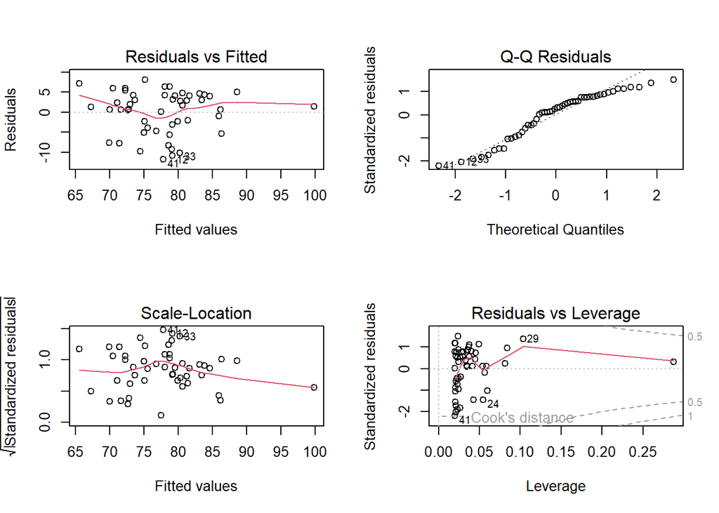

```r
# 回归诊断示例

# 残差分析
par(mfrow = c(2, 2))
plot(lm_model)
```

```r
par(mfrow = c(1, 1))

# 提取诊断统计量
diagnostics <- augment(lm_model)
head(diagnostics)
```

```
## # A tibble: 6 × 8
##   weight height .fitted .resid   .hat .sigma .cooksd .std.resid
##    <dbl>  <dbl>   <dbl>  <dbl>  <dbl>  <dbl>   <dbl>      <dbl>
## 1   83.2   169.    75.2  8.07  0.0239   5.34 0.0279       1.51
## 2   76.1   174.    79.2 -3.11  0.0210   5.45 0.00361     -0.580
## 3   88.2   180.    83.8  4.35  0.0400   5.43 0.0140       0.821
## 4   85.1   173.    78.7  6.35  0.0205   5.39 0.0147       1.18
## 5   85.0   183.    86.0 -0.984 0.0566   5.47 0.00105     -0.187
## 6   85.7   177.    81.7  4.02  0.0282   5.44 0.00823      0.753
```

```r
# 残差
residuals(lm_model)
```

```
##            1            2            3            4            5            6
##   8.07105975  -3.10841787   4.35494657   6.34796049  -0.98433690   4.01932230
##            7            8            9           10           11           12
##   0.77936225   0.65445868   0.45311388  -5.33170000   1.41843633 -10.86676289
##           13           14           15           16           17           18
##   5.96328697  -5.12153466   5.95673597  -2.06528622   5.36220703   2.70322455
##           19           20           21           22           23           24
##   3.04767940   4.17806352  -9.24528044  -8.23728182  -3.96093892  -7.65683211
##           25           26           27           28           29           30
##   4.16058354  -7.71815307   3.94227627   5.02499606   7.09754238   6.35363091
##           31           32           33           34           35           36
##   1.74261734   1.28441220 -10.16583885   2.37686092  -4.71091345  -9.77836835
##           37           38           39           40           41           42
##   3.17719223   0.57784113   4.59433949  -5.64918821 -11.77487940   3.04018748
##           43           44           45           46           47           48
##   2.90806488  -2.36558877   2.01520955   0.06689361  -2.36764488   4.72141066
##           49           50
##   4.08959830   0.62543217
```

```r
# 标准化残差
rstandard(lm_model)
```

```
##           1           2           3           4           5           6
##  1.50871289 -0.58018808  0.82084654  1.18453383 -0.18716361  0.75299828
##           7           8           9          10          11          12
##  0.14644224  0.12455545  0.08517070 -1.01552521  0.31036406 -2.02826074
##          13          14          15          16          17          18
##  1.12240406 -0.95754002  1.12840310 -0.38670764  1.00917510  0.50517043
##          19          20          21          22          23          24
##  0.57136552  0.78367883 -1.72555620 -1.53700156 -0.73999903 -1.45430761
##          25          26          27          28          29          30
##  0.77619507 -1.45685078  0.74523615  0.96946295  1.38423615  1.18532460
##          31          32          33          34          35          36
##  0.32582715  0.24745478 -1.89956664  0.44913897 -0.87910444 -1.83001057
##          37          38          39          40          41          42
##  0.59306217  0.10972123  0.86389336 -1.05413631 -2.19668240  0.57226561
##          43          44          45          46          47          48
##  0.54432397 -0.44188486  0.37845540  0.01247989 -0.44262163  0.88280819
##          49          50
##  0.76356334  0.11796197
```

```r
# 学生化残差
rstudent(lm_model)
```

```
##           1           2           3           4           5           6
##  1.52962312 -0.57613639  0.81801268  1.18964663 -0.18527134  0.74955352
##           7           8           9          10          11          12
##  0.14494115  0.12327109  0.08428520 -1.01586343  0.30742271 -2.09898305
##          13          14          15          16          17          18
##  1.12551901 -0.95669447  1.13169818 -0.38325571  1.00937307  0.50121470
##          19          20          21          22          23          24
##  0.56731498  0.78048169 -1.76304520 -1.55977414 -0.73646308 -1.47187147
##          25          26          27          28          29          30
##  0.77293326 -1.47456432  0.74173597  0.96884328  1.39792718  1.19046476
##          31          32          33          34          35          36
##  0.32277240  0.24501990 -1.95457724  0.44537267 -0.87698752 -1.87752892
##          37          38          39          40          41          42
##  0.58901391  0.10858590  0.86157127 -1.05538559 -2.29193400  0.56821482
##          43          44          45          46          47          48
##  0.54029420 -0.43814977  0.37505238  0.01234922 -0.43888329  0.88074321
##          49          50
##  0.76019865  0.11674365
```

```r
# 杠杆值（hat values）
hatvalues(lm_model)
```

```
##          1          2          3          4          5          6          7
## 0.02389756 0.02098654 0.03996030 0.02046272 0.05660797 0.02822624 0.03396364
##          8          9         10         11         12         13         14
## 0.05835658 0.03465663 0.05984931 0.28759935 0.02096034 0.03723470 0.02426062
##         15         16         17         18         19         20         21
## 0.04953609 0.02715768 0.03705479 0.02335694 0.02958395 0.03055915 0.02089463
##         22         23         24         25         26         27         28
## 0.02035956 0.02280449 0.05456174 0.02002679 0.04270871 0.04554874 0.08366032
##         29         30         31         32         33         34         35
## 0.10330843 0.02002084 0.02438831 0.08110770 0.02315683 0.04480171 0.02056238
##         36         37         38         39         40         41         42
## 0.02619262 0.02110972 0.05401760 0.03534201 0.02045134 0.02000047 0.03738437
##         43         44         45         46         47         48         49
## 0.02648927 0.02252035 0.03292870 0.02006929 0.02407748 0.02443028 0.02159506
##         50
## 0.04120911
```

```r
# Cook距离
cooks.distance(lm_model)
```

```
##            1            2            3            4            5            6
## 2.786387e-02 3.607945e-03 1.402276e-02 1.465573e-02 1.050989e-03 8.234663e-03
##            7            8            9           10           11           12
## 3.769845e-04 4.807274e-04 1.302132e-04 3.282563e-02 1.944359e-02 4.403679e-02
##           13           14           15           16           17           18
## 2.436104e-02 1.139861e-02 3.318063e-02 2.087304e-03 1.959503e-02 3.051588e-03
##           19           20           21           22           23           24
## 4.976181e-03 9.679797e-03 3.177118e-02 2.454824e-02 6.389564e-03 6.102919e-02
##           25           26           27           28           29           30
## 6.156146e-03 4.734482e-02 1.325197e-02 4.290377e-02 1.103781e-01 1.435192e-02
##           31           32           33           34           35           36
## 1.326934e-03 2.702460e-03 4.276941e-02 4.730778e-03 8.112367e-03 4.503841e-02
##           37           38           39           40           41           42
## 3.792442e-03 3.437190e-04 1.367125e-02 1.160003e-02 4.924010e-02 6.359199e-03
##           43           44           45           46           47           48
## 4.031013e-03 2.249343e-03 2.438459e-03 1.594880e-06 2.416746e-03 9.758270e-03
##           49           50
## 6.434220e-03 2.990359e-04
```

```r
# 识别异常点
# 高杠杆点（大于2p/n）
n <- nrow(body_data)
p <- 2  # 参数个数
leverage_threshold <- 2 * p / n
high_leverage <- which(hatvalues(lm_model) > leverage_threshold)
cat("高杠杆点:", high_leverage, "\n")
```

```
## 高杠杆点: 11 28 29 32
```

```r
# 影响点（Cook距离 > 4/n）
cook_threshold <- 4 / n
influential <- which(cooks.distance(lm_model) > cook_threshold)
cat("影响点:", influential, "\n")
```

```
## 影响点: 29
```

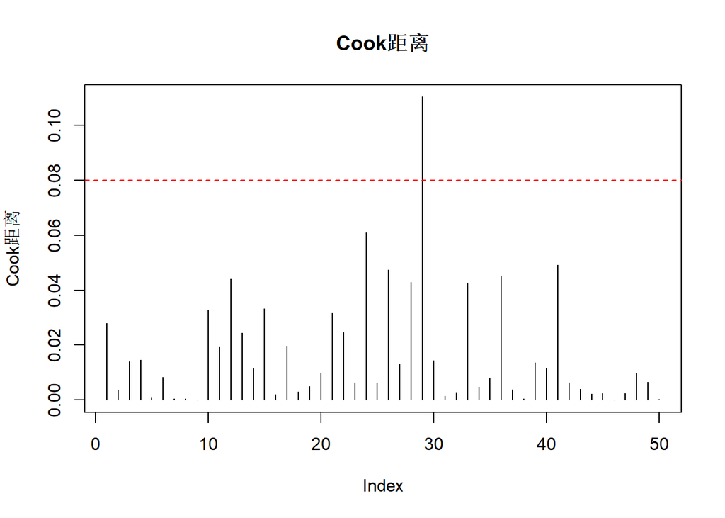

```r
# 可视化Cook距离
plot(cooks.distance(lm_model), type = "h",
     main = "Cook距离", ylab = "Cook距离")
abline(h = cook_threshold, col = "red", lty = 2)
```

## 8.7 多元线性回归基础

### 数学基础

**多元回归模型**：
$$Y =
\beta_0 + \beta_1 X_1 + \beta_2 X_2 + ... + \beta_p X_p +
\epsilon$$

```r
# 多元线性回归示例
# 场景：预测血压（基于年龄、体重、运动时间）

set.seed(666666)
n <- 100

age <- rnorm(n, mean = 50, sd = 10)
weight <- rnorm(n, mean = 70, sd = 12)
exercise <- rnorm(n, mean = 3, sd = 1.5)  # 每周运动小时数

# 血压模型
bp <- 80 + 0.5 * age + 0.3 * weight - 2 * exercise + rnorm(n, sd = 5)

bp_data <- data.frame(
  bp = bp,
  age = age,
  weight = weight,
  exercise = exercise
)

# 多元回归
lm_multi <- lm(bp ~ age + weight + exercise, data = bp_data)
summary(lm_multi)
```

```
##
## Call:
## lm(formula = bp ~ age + weight + exercise, data = bp_data)
##
## Residuals:
##      Min       1Q   Median       3Q      Max
## -10.7378  -3.5813  -0.0857   3.9048  12.0688
##
## Coefficients:
##             Estimate Std. Error t value Pr(>|t|)
## (Intercept) 77.29303    4.22257  18.305  < 2e-16 ***
## age          0.49361    0.05248   9.406 2.82e-15 ***
## weight       0.32083    0.04129   7.771 8.65e-12 ***
## exercise    -1.67331    0.34683  -4.825 5.27e-06 ***
## ---
## Signif. codes:  0 '***' 0.001 '**' 0.01 '*' 0.05 '.' 0.1 ' ' 1
##
## Residual standard error: 5.251 on 96 degrees of freedom
## Multiple R-squared:  0.6259, Adjusted R-squared:  0.6142
## F-statistic: 53.55 on 3 and 96 DF,  p-value: < 2.2e-16
```

```r
# 标准化回归系数
library(lm.beta)
lm.beta(lm_multi)
```

```
##
## Call:
## lm(formula = bp ~ age + weight + exercise, data = bp_data)
##
## Standardized Coefficients::
## (Intercept)         age      weight    exercise
##          NA   0.5898026   0.4872280  -0.3012182
```

```r
# 模型比较（使用anova）
lm_age <- lm(bp ~ age, data = bp_data)
lm_age_weight <- lm(bp ~ age + weight, data = bp_data)
lm_full <- lm(bp ~ age + weight + exercise, data = bp_data)

anova(lm_age, lm_age_weight, lm_full)
```

```
## Analysis of Variance Table
##
## Model 1: bp ~ age
## Model 2: bp ~ age + weight
## Model 3: bp ~ age + weight + exercise
##   Res.Df    RSS Df Sum of Sq      F    Pr(>F)
## 1     98 4938.3
## 2     97 3288.6  1   1649.69 59.833 1.028e-11 ***
## 3     96 2646.9  1    641.77 23.277 5.274e-06 ***
## ---
## Signif. codes:  0 '***' 0.001 '**' 0.01 '*' 0.05 '.' 0.1 ' ' 1
```

```r
# AIC比较
AIC(lm_age, lm_age_weight, lm_full)
```

```
##               df      AIC
## lm_age         3 679.7489
## lm_age_weight  4 641.0935
## lm_full        5 621.3837
```

## 8.8 回归中分类变量的处理

### 虚拟变量

```r
# 分类变量回归示例
set.seed(777777)
n <- 60

# 生成数据
treatment <- factor(rep(c("A", "B", "C"), each = 20))
effect <- ifelse(treatment == "A", 10,
                 ifelse(treatment == "B", 15, 12)) + rnorm(n, sd = 2)

cat_data <- data.frame(
  treatment = treatment,
  effect = effect
)

# 使用虚拟变量的回归
lm_cat <- lm(effect ~ treatment, data = cat_data)
summary(lm_cat)
```

```
##
## Call:
## lm(formula = effect ~ treatment, data = cat_data)
##
## Residuals:
##     Min      1Q  Median      3Q     Max
## -6.7255 -1.1945 -0.1065  1.3797  6.4063
##
## Coefficients:
##             Estimate Std. Error t value Pr(>|t|)
## (Intercept)   9.5484     0.5055  18.887  < 2e-16 ***
## treatmentB    5.2298     0.7149   7.315 9.50e-10 ***
## treatmentC    3.0903     0.7149   4.322 6.26e-05 ***
## ---
## Signif. codes:  0 '***' 0.001 '**' 0.01 '*' 0.05 '.' 0.1 ' ' 1
##
## Residual standard error: 2.261 on 57 degrees of freedom
## Multiple R-squared:  0.4869, Adjusted R-squared:  0.4689
## F-statistic: 27.05 on 2 and 57 DF,  p-value: 5.494e-09
```

```r
# 对比矩阵
contrasts(cat_data$treatment)
```

```
##   B C
## A 0 0
## B 1 0
## C 0 1
```

```r
# 更改参照组
cat_data$treatment <- relevel(cat_data$treatment, ref = "B")
lm_cat2 <- lm(effect ~ treatment, data = cat_data)
summary(lm_cat2)
```

```
##
## Call:
## lm(formula = effect ~ treatment, data = cat_data)
##
## Residuals:
##     Min      1Q  Median      3Q     Max
## -6.7255 -1.1945 -0.1065  1.3797  6.4063
##
## Coefficients:
##             Estimate Std. Error t value Pr(>|t|)
## (Intercept)  14.7782     0.5055  29.232  < 2e-16 ***
## treatmentA   -5.2298     0.7149  -7.315  9.5e-10 ***
## treatmentC   -2.1395     0.7149  -2.993  0.00408 **
## ---
## Signif. codes:  0 '***' 0.001 '**' 0.01 '*' 0.05 '.' 0.1 ' ' 1
##
## Residual standard error: 2.261 on 57 degrees of freedom
## Multiple R-squared:  0.4869, Adjusted R-squared:  0.4689
## F-statistic: 27.05 on 2 and 57 DF,  p-value: 5.494e-09
```

```r
# 使用emmeans进行边际均值比较
library(emmeans)
emmeans(lm_cat, pairwise ~ treatment)
```

```
## $emmeans
##  treatment emmean    SE df lower.CL upper.CL
##  A           9.55 0.506 57     8.54     10.6
##  B          14.78 0.506 57    13.77     15.8
##  C          12.64 0.506 57    11.63     13.7
##
## Confidence level used: 0.95
##
## $contrasts
##  contrast estimate    SE df t.ratio p.value
##  A - B       -5.23 0.715 57  -7.315 <0.0001
##  A - C       -3.09 0.715 57  -4.322  0.0002
##  B - C        2.14 0.715 57   2.993  0.0112
##
## P value adjustment: tukey method for comparing a family of 3 estimates
```

## 8.9 稳健相关方法

```r
# 稳健相关示例
set.seed(888888)

# 生成含异常值的数据
x <- rnorm(50)
y <- 0.7 * x + rnorm(50, sd = 0.5)

# 添加异常值
x[1:3] <- c(5, -5, 6)
y[1:3] <- c(-3, 4, -2)

# Pearson相关（受异常值影响）
cor_pearson <- cor.test(x, y)

# Spearman相关（稳健）
cor_spearman <- cor.test(x, y, method = "spearman")

# Kendall's tau（稳健）
cor_kendall <- cor.test(x, y, method = "kendall")

# 比较
cat("Pearson r:", cor_pearson$estimate, "p =", cor_pearson$p.value, "\n")
```

```
## Pearson r: -0.3652727 p = 0.009097938
```

```r
cat("Spearman rho:", cor_spearman$estimate, "p =", cor_spearman$p.value, "\n")
```

```
## Spearman rho: 0.4287635 p = 0.002067728
```

```r
cat("Kendall tau:", cor_kendall$estimate, "p =", cor_kendall$p.value, "\n")
```

```
## Kendall tau: 0.3714286 p = 0.0001412265
```

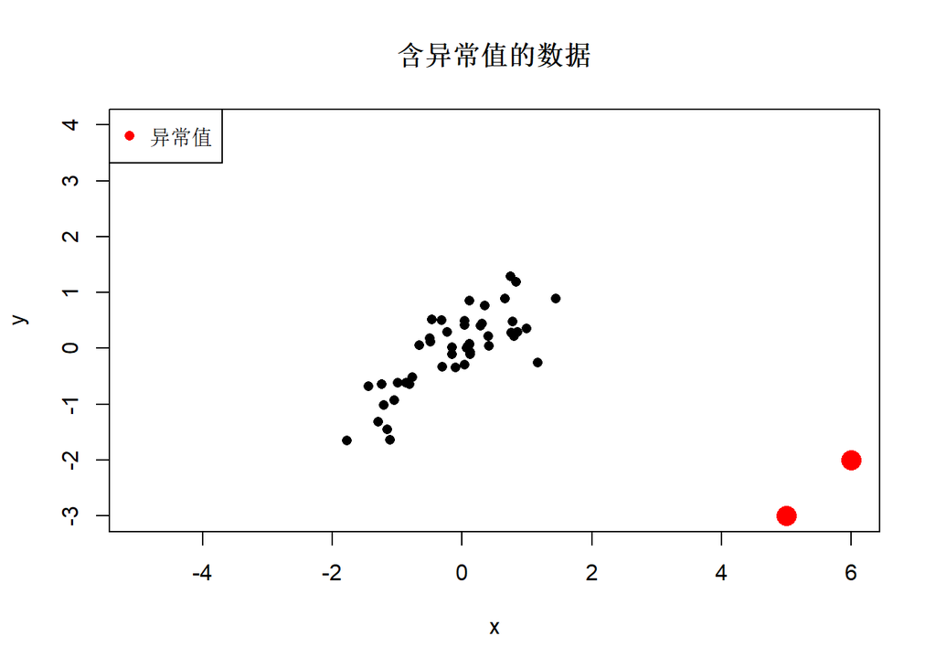

```r
# 可视化
plot(x, y, main = "含异常值的数据", pch = 16)
points(x[1:3], y[1:3], col = "red", pch = 16, cex = 2)
legend("topleft", legend = "异常值", col = "red", pch = 16)
```

## 第八章小结

[output not shown]

# 第九章：样本量与功效分析

功效分析是研究设计的重要组成部分，帮助确定研究所需的样本量，并评估检测到真实效应的能力。

## 9.1 功效分析基本概念

### 数学基础

**关键概念**：

1. **效应量（Effect Size）**：效应的实际大小，独立于样本量
2. **显著性水平（α）**：第I类错误概率，通常设为0.05
3. **功效（Power）**：正确拒绝错误H₀的概率，1-β
4. **样本量（n）**：研究中观测值的数量

**四者关系**：已知任意三个，可以计算第四个。

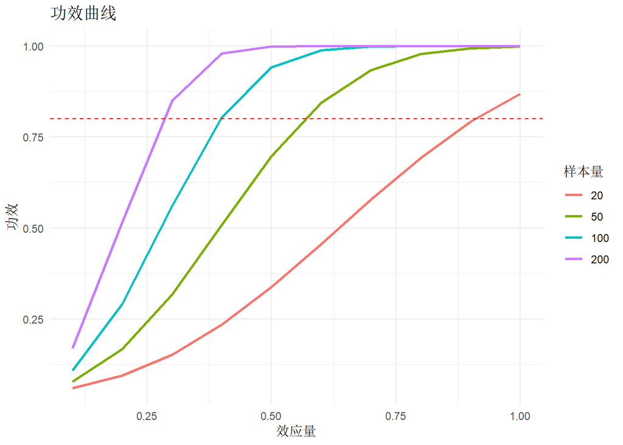

```r
# 功效分析基本概念演示
library(pwr)

# 功效曲线
effect_sizes <- seq(0.1, 1, by = 0.1)
n_values <- c(20, 50, 100, 200)

power_curves <- data.frame()
for (n in n_values) {
  for (d in effect_sizes) {
    power <- pwr.t.test(d = d, n = n, sig.level = 0.05,
                        type = "two.sample")$power
    power_curves <- rbind(power_curves,
                          data.frame(n = n, d = d, power = power))
  }
}

# 可视化功效曲线
ggplot2::ggplot(power_curves, ggplot2::aes(x = d, y = power, color = factor(n))) +
  ggplot2::geom_line(size = 1) +
  ggplot2::geom_hline(yintercept = 0.8, linetype = "dashed", color = "red") +
  ggplot2::labs(title = "功效曲线",
       x = "效应量",
       y = "功效",
       color = "样本量") +
  ggplot2::theme_minimal()
```

## 9.2 单样本t检验的功效与样本量

```r
# 单样本t检验功效分析示例
# 场景：检验血压是否不同于标准值

# 已知效应量，计算所需样本量
# 假设效应量d = 0.5（中等效应）
pwr_one_sample <- pwr.t.test(
  d = 0.5,           # 效应量
  sig.level = 0.05,  # 显著性水平
  power = 0.8,       # 期望功效
  type = "one.sample"
)
pwr_one_sample
```

```
##
##      One-sample t test power calculation
##
##               n = 33.36713
##               d = 0.5
##       sig.level = 0.05
##           power = 0.8
##     alternative = two.sided
```

```r
# 已知样本量，计算功效
pwr_one_sample2 <- pwr.t.test(
  d = 0.5,
  n = 30,
  sig.level = 0.05,
  type = "one.sample"
)
pwr_one_sample2
```

```
##
##      One-sample t test power calculation
##
##               n = 30
##               d = 0.5
##       sig.level = 0.05
##           power = 0.7539647
##     alternative = two.sided
```

```r
# 已知样本量和功效，计算可检测的最小效应量
pwr_one_sample3 <- pwr.t.test(
  n = 50,
  power = 0.8,
  sig.level = 0.05,
  type = "one.sample"
)
pwr_one_sample3
```

```
##
##      One-sample t test power calculation
##
##               n = 50
##               d = 0.4041852
##       sig.level = 0.05
##           power = 0.8
##     alternative = two.sided
```

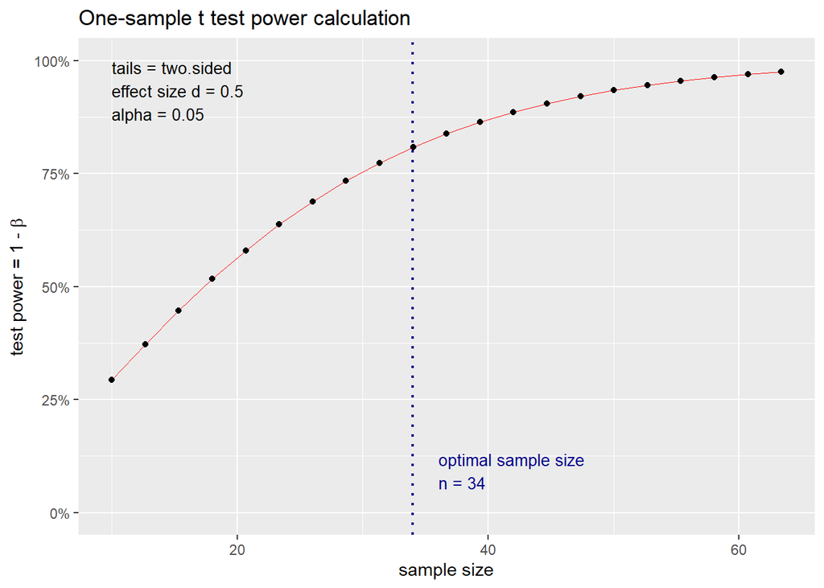

```r
# 可视化
plot(pwr_one_sample)
```

## 9.3 两样本t检验的功效与样本量

```r
# 两样本t检验功效分析示例
# 场景：比较两种药物的疗效

# 计算所需样本量
pwr_two_sample <- pwr.t.test(
  d = 0.5,           # 中等效应量
  sig.level = 0.05,
  power = 0.8,
  type = "two.sample"
)
pwr_two_sample
```

```
##
##      Two-sample t test power calculation
##
##               n = 63.76561
##               d = 0.5
##       sig.level = 0.05
##           power = 0.8
##     alternative = two.sided
##
## NOTE: n is number in *each* group
```

```r
# 配对样本t检验
pwr_paired <- pwr.t.test(
  d = 0.5,
  sig.level = 0.05,
  power = 0.8,
  type = "paired"
)
pwr_paired
```

```
##
##      Paired t test power calculation
##
##               n = 33.36713
##               d = 0.5
##       sig.level = 0.05
##           power = 0.8
##     alternative = two.sided
##
## NOTE: n is number of *pairs*
```

```r
# 比较独立样本与配对样本所需样本量
cat("独立样本每组需要:", ceiling(pwr_two_sample$n), "人\n")
```

```
## 独立样本每组需要: 64 人
```

```r
cat("配对样本需要:", ceiling(pwr_paired$n), "对\n")
```

```
## 配对样本需要: 34 对
```

```r
# 不等样本量（已知n1，计算n2）
pwr_unequal <- pwr.t2n.test(
  n1 = 50,
  n2 = NULL,         # 需要计算n2
  d = 0.5,
  sig.level = 0.05,
  power = 0.8
)
pwr_unequal
```

```
##
##      t test power calculation
##
##              n1 = 50
##              n2 = 87.70891
##               d = 0.5
##       sig.level = 0.05
##           power = 0.8
##     alternative = two.sided
```

## 9.4 方差分析的功效与样本量

```r
# ANOVA功效分析示例
# 场景：比较三种治疗方法

# 计算所需样本量
# 效应量f = 0.25（中等效应）
pwr_anova <- pwr.anova.test(
  k = 3,              # 组数
  f = 0.25,           # 效应量
  sig.level = 0.05,
  power = 0.8
)
pwr_anova
```

```
##
##      Balanced one-way analysis of variance power calculation
##
##               k = 3
##               n = 52.3966
##               f = 0.25
##       sig.level = 0.05
##           power = 0.8
##
## NOTE: n is number in each group
```

```r
# 计算给定样本量的功效
pwr_anova2 <- pwr.anova.test(
  k = 3,
  n = 20,             # 每组样本量
  f = 0.25,
  sig.level = 0.05
)
pwr_anova2
```

```
##
##      Balanced one-way analysis of variance power calculation
##
##               k = 3
##               n = 20
##               f = 0.25
##       sig.level = 0.05
##           power = 0.3744311
##
## NOTE: n is number in each group
```

```r
# Cohen's f的解释
# f = 0.1: 小效应
# f = 0.25: 中等效应
# f = 0.4: 大效应

# 从η²计算f
eta_sq <- 0.06  # 假设η² = 0.06
f_from_eta <- sqrt(eta_sq / (1 - eta_sq))
cat("η² =", eta_sq, "对应的f =", f_from_eta, "\n")
```

```
## η² = 0.06 对应的f = 0.2526456
```

## 9.5 比例检验的样本量计算

```r
# 比例检验功效分析示例
# 场景：比较两组治愈率

# 单样本比例检验
# 检验比例是否不同于0.5
pwr_prop_single <- pwr.p.test(
  h = 0.3,            # 效应量h
  sig.level = 0.05,
  power = 0.8
)
pwr_prop_single
```

```
##
##      proportion power calculation for binomial distribution (arcsine transformation)
##
##               h = 0.3
##               n = 87.20956
##       sig.level = 0.05
##           power = 0.8
##     alternative = two.sided
```

```r
# 两样本比例检验
pwr_prop_two <- pwr.2p.test(
  h = 0.3,
  sig.level = 0.05,
  power = 0.8
)
pwr_prop_two
```

```
##
##      Difference of proportion power calculation for binomial distribution (arcsine transformation)
##
##               h = 0.3
##               n = 174.4191
##       sig.level = 0.05
##           power = 0.8
##     alternative = two.sided
##
## NOTE: same sample sizes
```

```r
# 从比例计算效应量h
p1 <- 0.6
p2 <- 0.4
h <- ES.h(p1, p2)
cat("p1 =", p1, "p2 =", p2, "效应量h =", h, "\n")
```

```
## p1 = 0.6 p2 = 0.4 效应量h = 0.4027158
```

```r
# 使用计算出的h计算样本量
pwr.2p.test(h = h, sig.level = 0.05, power = 0.8)
```

```
##
##      Difference of proportion power calculation for binomial distribution (arcsine transformation)
##
##               h = 0.4027158
##               n = 96.79194
##       sig.level = 0.05
##           power = 0.8
##     alternative = two.sided
##
## NOTE: same sample sizes
```

## 9.6 相关性检验的样本量

```r
# 相关性检验功效分析示例
# 场景：检验两个变量的相关性

# 计算所需样本量
pwr_cor <- pwr.r.test(
  r = 0.3,            # 期望相关系数
  sig.level = 0.05,
  power = 0.8
)
pwr_cor
```

```
##
##      approximate correlation power calculation (arctangh transformation)
##
##               n = 84.07364
##               r = 0.3
##       sig.level = 0.05
##           power = 0.8
##     alternative = two.sided
```

```r
# 计算给定样本量的功效
pwr_cor2 <- pwr.r.test(
  r = 0.3,
  n = 50,
  sig.level = 0.05
)
pwr_cor2
```

```
##
##      approximate correlation power calculation (arctangh transformation)
##
##               n = 50
##               r = 0.3
##       sig.level = 0.05
##           power = 0.5715558
##     alternative = two.sided
```

```r
# 可检测的最小相关系数
pwr_cor3 <- pwr.r.test(
  n = 100,
  sig.level = 0.05,
  power = 0.8
)
pwr_cor3
```

```
##
##      approximate correlation power calculation (arctangh transformation)
##
##               n = 100
##               r = 0.275866
##       sig.level = 0.05
##           power = 0.8
##     alternative = two.sided
```

```r
# 相关系数效应量解释
# r = 0.1: 小效应
# r = 0.3: 中等效应
# r = 0.5: 大效应
```

## 9.7 线性回归的样本量考虑

```r
# 线性回归功效分析示例
# 场景：多元回归

# 计算所需样本量
# f² = R²/(1-R²)
# 假设R² = 0.15，则f² = 0.15/0.85 ≈ 0.176

pwr_reg <- pwr.f2.test(
  u = 3,              # 预测变量个数
  v = NULL,           # 残差自由度（待计算）
  f2 = 0.176,         # 效应量f²
  sig.level = 0.05,
  power = 0.8
)
pwr_reg
```

```
##
##      Multiple regression power calculation
##
##               u = 3
##               v = 61.98755
##              f2 = 0.176
##       sig.level = 0.05
##           power = 0.8
```

```r
# 样本量 = u + v + 1
n_needed <- 3 + pwr_reg$v + 1
cat("所需样本量:", ceiling(n_needed), "\n")
```

```
## 所需样本量: 66
```

```r
# 经验法则
# 每个预测变量至少10-20个观测值
# n ≥ 10k 或 n ≥ 20k（k为预测变量数）

# Green公式
# n ≥ 50 + 8k（用于检验整体回归）
# n ≥ 104 + k（用于检验单个系数）
k <- 3
n_green1 <- 50 + 8 * k
n_green2 <- 104 + k
cat("Green公式（整体）:", n_green1, "\n")
```

```
## Green公式（整体）: 74
```

```r
cat("Green公式（单个系数）:", n_green2, "\n")
```

```
## Green公式（单个系数）: 107
```

## 9.8 使用pwr包进行功效分析总结

```r
# pwr包函数汇总

# 创建汇总表
pwr_functions <- data.frame(
  函数 = c("pwr.t.test()", "pwr.t2n.test()", "pwr.anova.test()",
           "pwr.p.test()", "pwr.2p.test()", "pwr.r.test()", "pwr.f2.test()"),
  用途 = c("单样本/两样本/配对t检验",
           "不等样本量两样本t检验",
           "单因素ANOVA",
           "单样本比例检验",
           "两样本比例检验",
           "相关性检验",
           "线性回归"),
  效应量 = c("d (Cohen's d)", "d", "f", "h", "h", "r", "f²")
)

pwr_functions
```

```
##               函数                    用途        效应量
## 1     pwr.t.test() 单样本/两样本/配对t检验 d (Cohen's d)
## 2   pwr.t2n.test()   不等样本量两样本t检验             d
## 3 pwr.anova.test()             单因素ANOVA             f
## 4     pwr.p.test()          单样本比例检验             h
## 5    pwr.2p.test()          两样本比例检验             h
## 6     pwr.r.test()              相关性检验             r
## 7    pwr.f2.test()                线性回归            f²
```

```r
# 效应量解释标准
effect_sizes <- data.frame(
  效应量 = c("d", "d", "d", "f", "f", "f", "r", "r", "r"),
  大小 = rep(c("小", "中", "大"), 3),
  值 = c(0.2, 0.5, 0.8, 0.1, 0.25, 0.4, 0.1, 0.3, 0.5)
)

effect_sizes
```

```
##   效应量 大小   值
## 1      d   小 0.20
## 2      d   中 0.50
## 3      d   大 0.80
## 4      f   小 0.10
## 5      f   中 0.25
## 6      f   大 0.40
## 7      r   小 0.10
## 8      r   中 0.30
## 9      r   大 0.50
```

## 第九章小结

| 检验类型 | 效应量 | R函数 | 关键参数 |
| --- | --- | --- | --- |
| t检验 | Cohen’s d | pwr.t.test() | d, n, power |
| ANOVA | Cohen’s f | pwr.anova.test() | k, f, n |
| 比例检验 | h | pwr.2p.test() | h, n, power |
| 相关检验 | r | pwr.r.test() | r, n, power |
| 回归 | f² | pwr.f2.test() | u, v, f² |

# 第十章：统计模拟与重采样方法

统计模拟和重采样方法是现代统计学的重要工具，它们通过计算机模拟来研究统计性质、估计参数和进行假设检验，特别适用于理论推导困难的情况。

## 10.1 蒙特卡洛模拟基础

### 数学基础

**蒙特卡洛方法**：通过大量随机模拟来估计统计量或验证统计性质。

**基本步骤**： 1. 定义统计模型 2. 生成随机样本 3. 计算统计量 4. 重复多次 5. 分析结果分布

```r
# 蒙特卡洛模拟基础示例
# 验证样本均值的性质

set.seed(12345)

# 模拟参数
n_sim <- 10000    # 模拟次数
n_sample <- 30    # 每次抽样的样本量
true_mean <- 100  # 真实均值
true_sd <- 15     # 真实标准差

# 存储结果
sample_means <- numeric(n_sim)

# 进行模拟
for (i in 1:n_sim) {
  sample_data <- rnorm(n_sample, mean = true_mean, sd = true_sd)
  sample_means[i] <- mean(sample_data)
}

# 分析结果
cat("模拟次数:", n_sim, "\n")
```

```
## 模拟次数: 10000
```

```r
cat("样本均值的理论期望:", true_mean, "\n")
```

```
## 样本均值的理论期望: 100
```

```r
cat("模拟均值的平均值:", mean(sample_means), "\n")
```

```
## 模拟均值的平均值: 100.03
```

```r
cat("样本均值的理论标准误:", true_sd / sqrt(n_sample), "\n")
```

```
## 样本均值的理论标准误: 2.738613
```

```r
cat("模拟均值的标准差:", sd(sample_means), "\n")
```

```
## 模拟均值的标准差: 2.734596
```

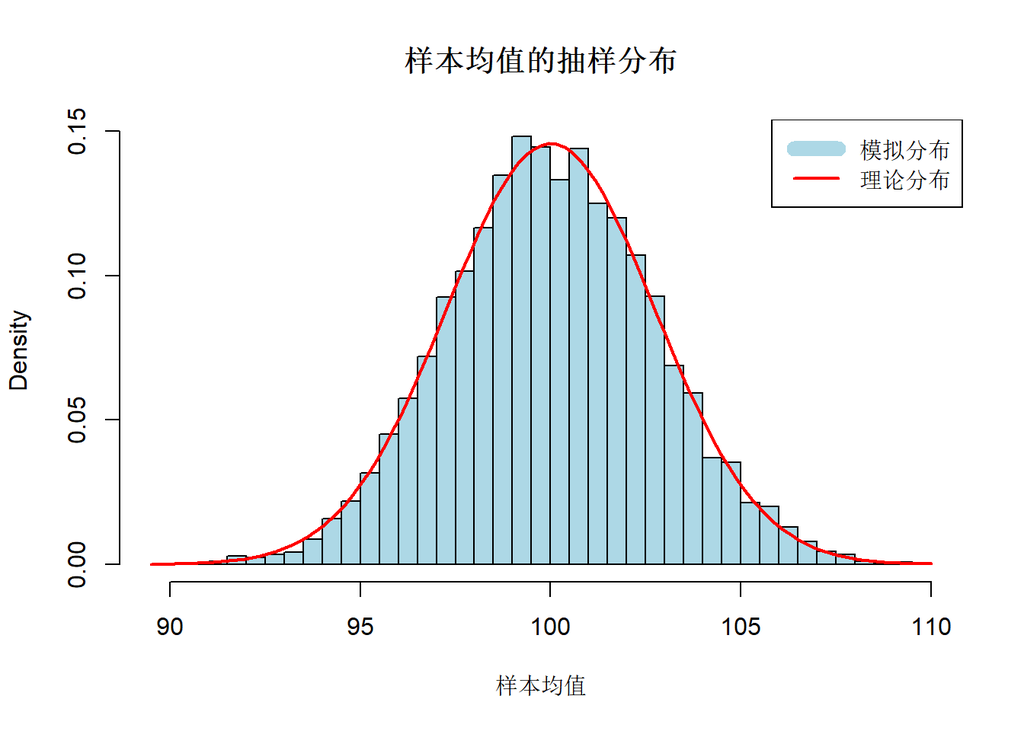

```r
# 可视化
hist(sample_means, breaks = 50, probability = TRUE,
     main = "样本均值的抽样分布",
     xlab = "样本均值", col = "lightblue")
curve(dnorm(x, mean = true_mean, sd = true_sd/sqrt(n_sample)),
      add = TRUE, col = "red", lwd = 2)
legend("topright", legend = c("模拟分布", "理论分布"),
       col = c("lightblue", "red"), lwd = c(10, 2))
```

## 10.2 模拟验证统计性质

### 验证中心极限定理

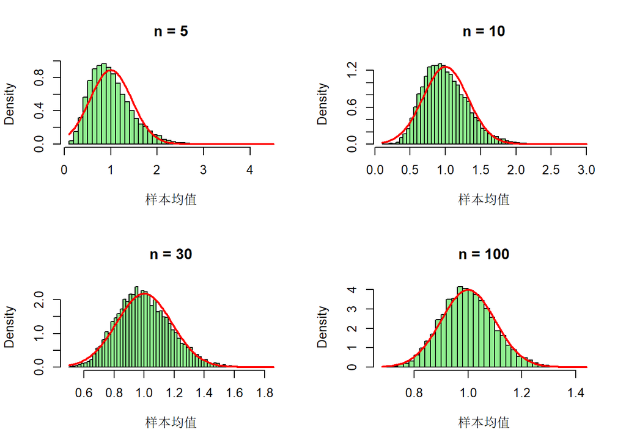

```r
# 验证中心极限定理
set.seed(23456)

# 从指数分布（非正态）抽样
n_sim <- 10000
n_values <- c(5, 10, 30, 100)

par(mfrow = c(2, 2))
for (n in n_values) {
  sample_means <- numeric(n_sim)
  for (i in 1:n_sim) {
    sample_means[i] <- mean(rexp(n, rate = 1))
  }

  hist(sample_means, breaks = 50, probability = TRUE,
       main = paste("n =", n),
       xlab = "样本均值", col = "lightgreen")

  # 理论正态分布
  curve(dnorm(x, mean = 1, sd = 1/sqrt(n)),
        add = TRUE, col = "red", lwd = 2)
}
```

```r
par(mfrow = c(1, 1))
```

### 验证t检验的性质

```r
# 验证t检验的第I类错误率
set.seed(34567)

n_sim <- 10000
n <- 20
alpha <- 0.05

type1_errors <- numeric(n_sim)

for (i in 1:n_sim) {
  # 从正态分布生成数据（H₀为真）
  data <- rnorm(n, mean = 0, sd = 1)

  # 进行t检验
  test_result <- t.test(data, mu = 0)

  # 记录是否拒绝H₀
  type1_errors[i] <- test_result$p.value < alpha
}

cat("理论第I类错误率:", alpha, "\n")
```

```
## 理论第I类错误率: 0.05
```

```r
cat("模拟第I类错误率:", mean(type1_errors), "\n")
```

```
## 模拟第I类错误率: 0.0547
```

```r
cat("95%置信区间:",
    binom.test(sum(type1_errors), n_sim, p = alpha)$conf.int, "\n")
```

```
## 95%置信区间: 0.05032338 0.05933816
```

## 10.3 自举法基础

### 数学基础

**自举法（Bootstrap）**：通过有放回重抽样来估计统计量的分布。

**基本步骤**： 1. 从原始样本中有放回抽取n个观测值 2. 计算统计量 3. 重复B次 4. 使用统计量分布进行推断

```r
# 自举法基础示例
# 估计中位数的标准误

set.seed(45678)

# 原始数据
original_data <- rnorm(50, mean = 100, sd = 20)

# 自举过程
n_boot <- 1000
boot_medians <- numeric(n_boot)

for (i in 1:n_boot) {
  boot_sample <- sample(original_data, size = length(original_data),
                        replace = TRUE)
  boot_medians[i] <- median(boot_sample)
}

# 结果
cat("原始样本中位数:", median(original_data), "\n")
```

```
## 原始样本中位数: 103.7049
```

```r
cat("自举中位数的均值:", mean(boot_medians), "\n")
```

```
## 自举中位数的均值: 100.7825
```

```r
cat("自举估计的标准误:", sd(boot_medians), "\n")
```

```
## 自举估计的标准误: 4.569661
```

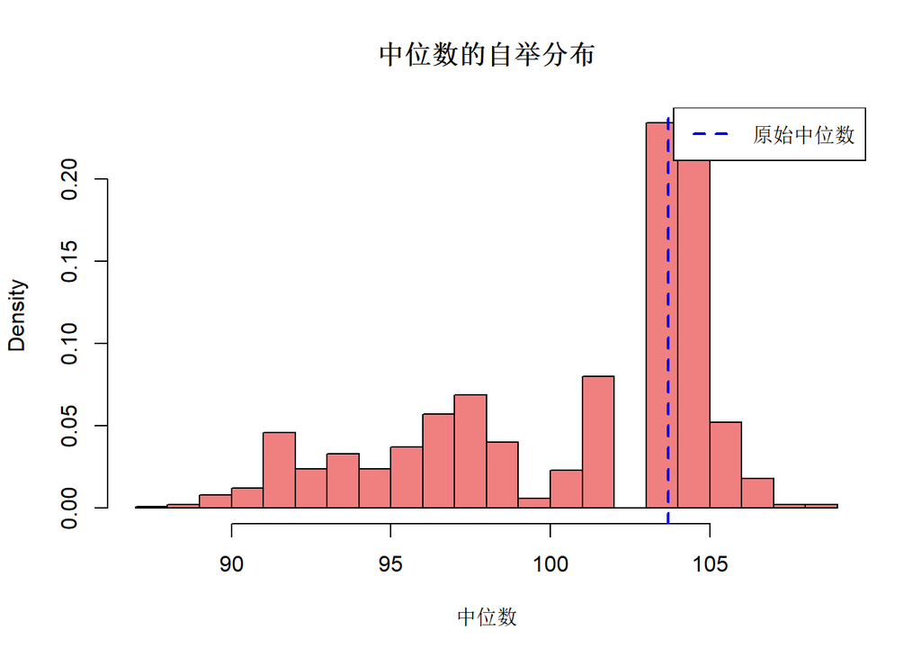

```r
# 可视化
hist(boot_medians, breaks = 30, probability = TRUE,
     main = "中位数的自举分布",
     xlab = "中位数", col = "lightcoral")
abline(v = median(original_data), col = "blue", lwd = 2, lty = 2)
legend("topright", legend = "原始中位数", col = "blue", lty = 2, lwd = 2)
```

## 10.4 使用boot包进行自举

```r
# 使用boot包示例
library(boot)

# 定义统计量函数
median_fun <- function(data, indices) {
  d <- data[indices]
  return(median(d))
}

# 进行自举
boot_result <- boot(data = original_data,
                    statistic = median_fun,
                    R = 1000)
boot_result
```

```
##
## ORDINARY NONPARAMETRIC BOOTSTRAP
##
##
## Call:
## boot(data = original_data, statistic = median_fun, R = 1000)
##
##
## Bootstrap Statistics :
##     original    bias    std. error
## t1* 103.7049 -2.820728    4.424422
```

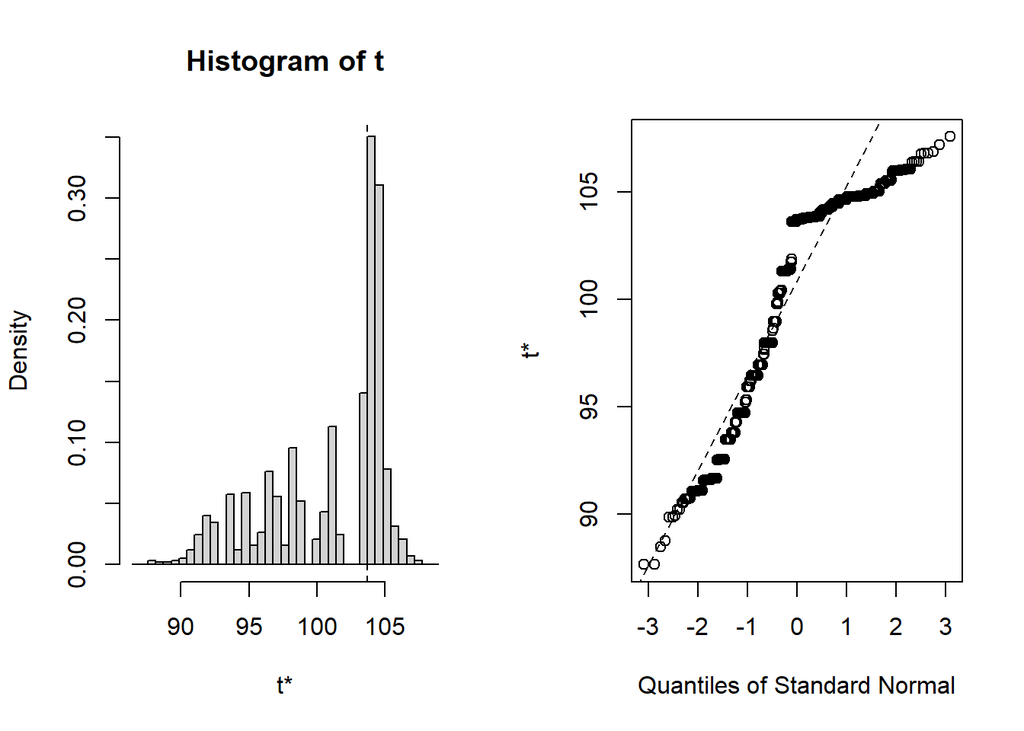

```r
# 查看自举分布
plot(boot_result)
```

```r
# 计算置信区间
# 正态近似
boot.ci(boot_result, type = "norm")
```

```
## BOOTSTRAP CONFIDENCE INTERVAL CALCULATIONS
## Based on 1000 bootstrap replicates
##
## CALL :
## boot.ci(boot.out = boot_result, type = "norm")
##
## Intervals :
## Level      Normal
## 95%   ( 97.9, 115.2 )
## Calculations and Intervals on Original Scale
```

```r
# 百分位数法
boot.ci(boot_result, type = "perc")
```

```
## BOOTSTRAP CONFIDENCE INTERVAL CALCULATIONS
## Based on 1000 bootstrap replicates
##
## CALL :
## boot.ci(boot.out = boot_result, type = "perc")
##
## Intervals :
## Level     Percentile
## 95%   ( 91.1, 106.0 )
## Calculations and Intervals on Original Scale
```

```r
# BCa法（偏差校正加速）
boot.ci(boot_result, type = "bca")
```

```
## BOOTSTRAP CONFIDENCE INTERVAL CALCULATIONS
## Based on 1000 bootstrap replicates
##
## CALL :
## boot.ci(boot.out = boot_result, type = "bca")
##
## Intervals :
## Level       BCa
## 95%   ( 91.1, 105.8 )
## Calculations and Intervals on Original Scale
```

## 10.5 自举法置信区间

### 不同置信区间方法比较

```r
# 自举置信区间方法比较
# 估计相关系数的置信区间

set.seed(56789)
n <- 50
x <- rnorm(n)
y <- 0.6 * x + rnorm(n, sd = 0.8)

# 定义相关系数函数
cor_fun <- function(data, indices) {
  d <- data[indices, ]
  cor(d[, 1], d[, 2])
}

# 创建数据框
cor_data <- data.frame(x = x, y = y)

# 自举
boot_cor <- boot(data = cor_data, statistic = cor_fun, R = 2000)
boot_cor
```

```
##
## ORDINARY NONPARAMETRIC BOOTSTRAP
##
##
## Call:
## boot(data = cor_data, statistic = cor_fun, R = 2000)
##
##
## Bootstrap Statistics :
##      original       bias    std. error
## t1* 0.6545179 -0.002059037  0.06285708
```

```r
# 不同方法的置信区间
cat("样本相关系数:", cor(x, y), "\n")
```

```
## 样本相关系数: 0.6545179
```

```r
cat("\n各种置信区间方法:\n")
```

```
##
## 各种置信区间方法:
```

```r
cat("正态近似:\n")
```

```
## 正态近似:
```

```r
print(boot.ci(boot_cor, type = "norm"))
```

```
## BOOTSTRAP CONFIDENCE INTERVAL CALCULATIONS
## Based on 2000 bootstrap replicates
##
## CALL :
## boot.ci(boot.out = boot_cor, type = "norm")
##
## Intervals :
## Level      Normal
## 95%   ( 0.5334,  0.7798 )
## Calculations and Intervals on Original Scale
```

```r
cat("\n百分位数法:\n")
```

```
##
## 百分位数法:
```

```r
print(boot.ci(boot_cor, type = "perc"))
```

```
## BOOTSTRAP CONFIDENCE INTERVAL CALCULATIONS
## Based on 2000 bootstrap replicates
##
## CALL :
## boot.ci(boot.out = boot_cor, type = "perc")
##
## Intervals :
## Level     Percentile
## 95%   ( 0.5082,  0.7585 )
## Calculations and Intervals on Original Scale
```

```r
cat("\nBCa法:\n")
```

```
##
## BCa法:
```

```r
print(boot.ci(boot_cor, type = "bca"))
```

```
## BOOTSTRAP CONFIDENCE INTERVAL CALCULATIONS
## Based on 2000 bootstrap replicates
##
## CALL :
## boot.ci(boot.out = boot_cor, type = "bca")
##
## Intervals :
## Level       BCa
## 95%   ( 0.4944,  0.7518 )
## Calculations and Intervals on Original Scale
```

```r
# 与传统方法比较
cat("\n传统Fisher Z变换置信区间:\n")
```

```
##
## 传统Fisher Z变换置信区间:
```

```r
cor_test <- cor.test(x, y)
print(cor_test$conf.int)
```

```
## [1] 0.4599689 0.7891038
## attr(,"conf.level")
## [1] 0.95
```

## 10.6 参数自举与非参数自举

### 非参数自举

```r
# 非参数自举示例
# 从数据本身重抽样

set.seed(67890)
sample_data <- rnorm(30, mean = 50, sd = 10)

# 非参数自举
nonparam_boot <- function(data, n_boot = 1000) {
  n <- length(data)
  boot_stats <- numeric(n_boot)

  for (i in 1:n_boot) {
    boot_sample <- sample(data, size = n, replace = TRUE)
    boot_stats[i] <- mean(boot_sample)
  }

  return(boot_stats)
}

np_result <- nonparam_boot(sample_data)
cat("非参数自举均值标准误:", sd(np_result), "\n")
```

```
## 非参数自举均值标准误: 1.899314
```

### 参数自举

```r
# 参数自举示例
# 从拟合的分布中生成数据

param_boot <- function(data, n_boot = 1000) {
  n <- length(data)

  # 估计参数
  mu_hat <- mean(data)
  sigma_hat <- sd(data)

  boot_stats <- numeric(n_boot)

  for (i in 1:n_boot) {
    # 从估计的分布中生成数据
    boot_sample <- rnorm(n, mean = mu_hat, sd = sigma_hat)
    boot_stats[i] <- mean(boot_sample)
  }

  return(boot_stats)
}

p_result <- param_boot(sample_data)
cat("参数自举均值标准误:", sd(p_result), "\n")
```

```
## 参数自举均值标准误: 1.862321
```

```r
# 比较
cat("理论标准误:", sd(sample_data) / sqrt(length(sample_data)), "\n")
```

```
## 理论标准误: 1.846826
```

## 10.7 置换检验基础

### 数学基础

**置换检验（Permutation Test）**：通过随机排列数据来构建检验统计量的零分布。

**基本步骤**： 1. 计算原始数据的检验统计量 2. 随机排列组标签 3. 计算排列后的统计量 4. 重复多次 5. 比较原始统计量与置换分布

```r
# 置换检验示例
# 比较两组均值

set.seed(78901)

# 生成数据
group1 <- rnorm(20, mean = 50, sd = 10)
group2 <- rnorm(20, mean = 55, sd = 10)

all_data <- c(group1, group2)
group_labels <- rep(c(1, 2), each = 20)

# 原始差异
obs_diff <- mean(group2) - mean(group1)
cat("观测到的组间差异:", obs_diff, "\n")
```

```
## 观测到的组间差异: -0.9269954
```

```r
# 置换检验
n_perm <- 10000
perm_diffs <- numeric(n_perm)

for (i in 1:n_perm) {
  perm_labels <- sample(group_labels)
  perm_diffs[i] <- mean(all_data[perm_labels == 2]) -
                   mean(all_data[perm_labels == 1])
}

# 计算p值
p_value <- mean(abs(perm_diffs) >= abs(obs_diff))
cat("置换检验p值:", p_value, "\n")
```

```
## 置换检验p值: 0.7505
```

```r
# 与t检验比较
t_result <- t.test(group1, group2)
cat("t检验p值:", t_result$p.value, "\n")
```

```
## t检验p值: 0.747373
```

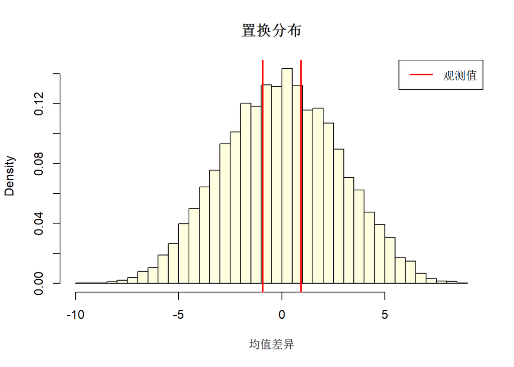

```r
# 可视化置换分布
hist(perm_diffs, breaks = 50, probability = TRUE,
     main = "置换分布",
     xlab = "均值差异", col = "lightyellow")
abline(v = obs_diff, col = "red", lwd = 2)
abline(v = -obs_diff, col = "red", lwd = 2)
legend("topright", legend = "观测值", col = "red", lwd = 2)
```

## 10.8 使用coin包进行置换检验

```r
# 使用coin包进行置换检验

# 创建数据框
perm_data <- data.frame(
  value = c(group1, group2),
  group = factor(rep(c("A", "B"), each = 20))
)

# 两独立样本置换检验
coin_result <- coin::oneway_test(value ~ group, data = perm_data,
                                  distribution = approximate(nresample = 10000))
coin_result
```

```
##
##  Approximative Two-Sample Fisher-Pitman Permutation Test
##
## data:  value by group (A, B)
## Z = 0.32834, p-value = 0.7537
## alternative hypothesis: true mu is not equal to 0
```

```r
# Wilcoxon-Mann-Whitney置换检验
coin_wilcox <- coin::wilcox_test(value ~ group, data = perm_data,
                                  distribution = approximate(nresample = 10000))
coin_wilcox
```

```
##
##  Approximative Wilcoxon-Mann-Whitney Test
##
## data:  value by group (A, B)
## Z = 0.2164, p-value = 0.8436
## alternative hypothesis: true mu is not equal to 0
```

```r
# 多组比较置换检验
set.seed(89012)
group_A <- rnorm(15, mean = 50, sd = 8)
group_B <- rnorm(15, mean = 55, sd = 8)
group_C <- rnorm(15, mean = 60, sd = 8)

anova_perm_data <- data.frame(
  value = c(group_A, group_B, group_C),
  group = factor(rep(c("A", "B", "C"), each = 15))
)

# Kruskal-Wallis置换检验
coin_kw <- coin::kruskal_test(value ~ group, data = anova_perm_data,
                               distribution = approximate(nresample = 10000))
coin_kw
```

```
##
##  Approximative Kruskal-Wallis Test
##
## data:  value by group (A, B, C)
## chi-squared = 19.831, p-value < 1e-04
```

## 10.9 交叉验证基础

### 数学基础

**交叉验证**：评估模型在独立数据上的表现，防止过拟合。

**K折交叉验证**： 1. 将数据分成K份 2. 用K-1份训练，1份验证 3. 重复K次 4. 平均结果

```r
# 交叉验证示例
# 线性回归的K折交叉验证

set.seed(90123)
n <- 100
cv_data <- data.frame(
  x1 = rnorm(n),
  x2 = rnorm(n),
  y = 2 * rnorm(n) + rnorm(n) + rnorm(n, sd = 0.5)
)

# K折交叉验证函数
k_fold_cv <- function(data, k = 5) {
  n <- nrow(data)
  fold_size <- n %/% k

  # 随机分配折
  folds <- sample(rep(1:k, length.out = n))

  mse_values <- numeric(k)

  for (i in 1:k) {
    # 分割数据
    test_idx <- which(folds == i)
    train_data <- data[-test_idx, ]
    test_data <- data[test_idx, ]

    # 训练模型
    model <- lm(y ~ x1 + x2, data = train_data)

    # 预测并计算误差
    predictions <- predict(model, newdata = test_data)
    mse_values[i] <- mean((test_data$y - predictions)^2)
  }

  return(list(
    mse = mse_values,
    mean_mse = mean(mse_values),
    sd_mse = sd(mse_values)
  ))
}

cv_result <- k_fold_cv(cv_data, k = 5)
cat("各折MSE:", cv_result$mse, "\n")
```

```
## 各折MSE: 5.632498 2.723833 6.574188 9.723657 4.461611
```

```r
cat("平均MSE:", cv_result$mean_mse, "\n")
```

```
## 平均MSE: 5.823157
```

```r
cat("MSE标准差:", cv_result$sd_mse, "\n")
```

```
## MSE标准差: 2.611222
```

```r
# 使用boot包的cv.glm
library(boot)
glm_model <- glm(y ~ x1 + x2, data = cv_data)
cv_glm_result <- cv.glm(cv_data, glm_model, K = 5)
cat("cv.glm估计的预测误差:", cv_glm_result$delta[1], "\n")
```

```
## cv.glm估计的预测误差: 6.135966
```

## 10.10 模拟在功效分析中的应用

```r
# 模拟功效分析示例
# 检验复杂设计的功效

set.seed(12345)

# 模拟函数：计算给定设计下的功效
simulate_power <- function(n_per_group, effect_size, n_sim = 1000, alpha = 0.05) {
  significant_count <- 0

  for (i in 1:n_sim) {
    # 生成数据
    group1 <- rnorm(n_per_group, mean = 0, sd = 1)
    group2 <- rnorm(n_per_group, mean = effect_size, sd = 1)

    # 进行检验
    test_result <- t.test(group1, group2)

    # 记录结果
    if (test_result$p.value < alpha) {
      significant_count <- significant_count + 1
    }
  }

  return(significant_count / n_sim)
}

# 不同样本量下的功效
sample_sizes <- c(20, 30, 50, 80, 100)
effect_size <- 0.5

powers <- sapply(sample_sizes, function(n) {
  simulate_power(n, effect_size, n_sim = 1000)
})

# 结果
power_df <- data.frame(
  n = sample_sizes,
  power = powers
)
print(power_df)
```

```
##     n power
## 1  20 0.340
## 2  30 0.492
## 3  50 0.696
## 4  80 0.889
## 5 100 0.940
```

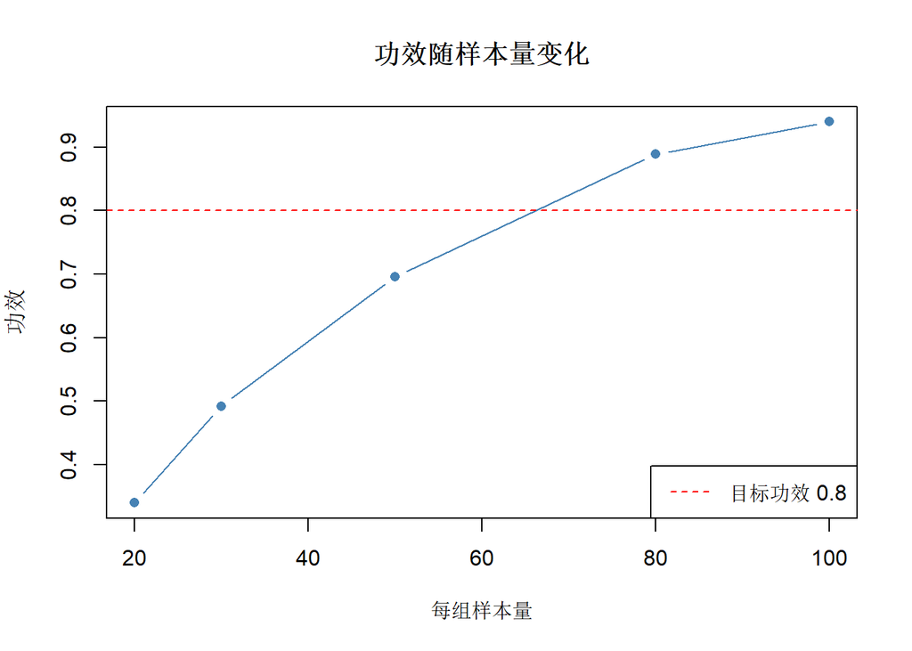

```r
# 可视化
plot(sample_sizes, powers, type = "b", pch = 16, col = "steelblue",
     main = "功效随样本量变化",
     xlab = "每组样本量", ylab = "功效")
abline(h = 0.8, col = "red", lty = 2)
legend("bottomright", legend = "目标功效 0.8", col = "red", lty = 2)
```

## 10.11 自举回归分析

```r
# 自举回归分析示例
set.seed(23456)

# 生成数据
n <- 50
x <- rnorm(n, mean = 50, sd = 10)
y <- 2 + 0.5 * x + rnorm(n, sd = 3)
reg_data <- data.frame(x = x, y = y)

# 定义回归系数函数
coef_fun <- function(data, indices) {
  d <- data[indices, ]
  model <- lm(y ~ x, data = d)
  return(coef(model))
}

# 自举
boot_reg <- boot(data = reg_data, statistic = coef_fun, R = 1000)
boot_reg
```

```
##
## ORDINARY NONPARAMETRIC BOOTSTRAP
##
##
## Call:
## boot(data = reg_data, statistic = coef_fun, R = 1000)
##
##
## Bootstrap Statistics :
##      original       bias    std. error
## t1* 1.3620514  0.100526667  1.81270720
## t2* 0.5015121 -0.001924008  0.03349922
```

```r
# 置信区间
cat("截距置信区间:\n")
```

```
## 截距置信区间:
```

```r
boot.ci(boot_reg, type = "bca", index = 1)
```

```
## BOOTSTRAP CONFIDENCE INTERVAL CALCULATIONS
## Based on 1000 bootstrap replicates
##
## CALL :
## boot.ci(boot.out = boot_reg, type = "bca", index = 1)
##
## Intervals :
## Level       BCa
## 95%   (-1.475,  6.123 )
## Calculations and Intervals on Original Scale
```

```r
cat("\n斜率置信区间:\n")
```

```
##
## 斜率置信区间:
```

```r
boot.ci(boot_reg, type = "bca", index = 2)
```

```
## BOOTSTRAP CONFIDENCE INTERVAL CALCULATIONS
## Based on 1000 bootstrap replicates
##
## CALL :
## boot.ci(boot.out = boot_reg, type = "bca", index = 2)
##
## Intervals :
## Level       BCa
## 95%   ( 0.4224,  0.5547 )
## Calculations and Intervals on Original Scale
```

```r
# 与传统方法比较
lm_model <- lm(y ~ x, data = reg_data)
confint(lm_model)
```

```
##                  2.5 %    97.5 %
## (Intercept) -2.1132767 4.8373794
## x            0.4345668 0.5684574
```

## 第十章小结

| 方法 | 用途 | R包/函数 | 优势 |
| --- | --- | --- | --- |
| 蒙特卡洛模拟 | 验证统计性质 | 自定义循环 | 灵活、直观 |
| 非参数自举 | 估计标准误/置信区间 | boot::boot() | 无需分布假设 |
| 参数自举 | 基于模型的重抽样 | 自定义函数 | 利用模型信息 |
| 置换检验 | 假设检验 | coin包 | 无需分布假设 |
| 交叉验证 | 模型评估 | boot::cv.glm() | 防止过拟合 |

**关键概念总结**：

1. **蒙特卡洛模拟**：通过大量随机模拟研究统计性质
2. **自举法**：通过有放回重抽样估计统计量的分布
3. **置换检验**：通过随机排列构建零分布
4. **交叉验证**：通过数据分割评估模型泛化能力

这些方法在现代统计学中非常重要，特别是当理论推导困难或传统假设不满足时。

# 全书总结

本书系统介绍了R语言统计分析的核心内容，涵盖了从描述性统计到高级统计方法的完整知识体系。

## 内容回顾

| 章节 | 主题 | 核心内容 |
| --- | --- | --- |
| 第一章 | 描述性统计 | 集中趋势、离散程度、分布形状 |
| 第二章 | 概率分布 | 常见分布、随机数生成、正态性检验 |
| 第三章 | 参数估计 | 点估计、置信区间、自举法 |
| 第四章 | 假设检验 | 基本概念、p值、效应量 |
| 第五章 | 参数检验 | t检验、比例检验、方差检验 |
| 第六章 | 非参数检验 | 秩检验、卡方检验、Fisher检验 |
| 第七章 | 方差分析 | 单因素、多因素、重复测量ANOVA |
| 第八章 | 相关与回归 | 相关系数、线性回归、回归诊断 |
| 第九章 | 功效分析 | 样本量计算、功效曲线 |
| 第十章 | 模拟方法 | 蒙特卡洛、自举、置换检验 |

## 学习建议

1. **理论与实践结合**：每学完一个概念，用R代码实践
2. **理解假设条件**：了解每种方法的适用条件
3. **关注效应量**：不仅仅关注p值，更要关注实际意义
4. **掌握多种方法**：参数与非参数方法都要掌握
5. **善用可视化**：图形化展示数据和分析结果

## 常用R包速查

```r
# 常用统计包汇总
packages_summary <- data.frame(
  包名 = c("stats", "dplyr", "ggplot2", "psych", "car",
           "pwr", "boot", "coin", "rstatix", "DescTools"),
  主要功能 = c("基础统计函数", "数据处理", "可视化", "心理统计", "回归诊断",
               "功效分析", "自举法", "置换检验", "现代统计检验", "描述统计工具")
)
packages_summary
```

```
##         包名     主要功能
## 1      stats 基础统计函数
## 2      dplyr     数据处理
## 3    ggplot2       可视化
## 4      psych     心理统计
## 5        car     回归诊断
## 6        pwr     功效分析
## 7       boot       自举法
## 8       coin     置换检验
## 9    rstatix 现代统计检验
## 10 DescTools 描述统计工具
```

希望本书能帮助您建立扎实的统计分析基础，并在实际研究中灵活运用！